# PAM Booster: PAM User Guide

Radiant Logic

# Introduction

PAM Booster allows the mapping and monitoring of the evolution of risks related to privileged accounts. Based on a snapshot of the CyberArk PAM and/or Privilege Cloud configuration, including HR data and Active Directory, PAM Booster creates a 360-degree view of identities and assets accessed through privileged accounts.

When looking at a privileged account, the access chain is reconstructed so that it is possible to understand who is using it, including the necessary context to determine the relevance of these authorizations as well as to understand to which asset in the company this privileged account corresponds. In the example of a database server privileged account, PAM Booster can track:

- the department to which the person who owns the account belongs, his or her job, whether the person is a service provider, etc., as well as
- the business applications and processes of the company indirectly impacted by this account.

The service provides checks on privileged accounts, the CyberArk configuration as well as access in relation to the security policy. Remediation advice is given and may target the privileged accounts, CyberArk access configuration or the structure of Active Directory.

All these elements are part of a concept known as “Get Clean” which aims to reduce the risks identified through controls. Secondly, since the company’s activities (organization, business, etc.) as well as its applications are likely to change, CyberArk accesses must be constantly monitored and re-evaluated to “Stay Clean.”

To do this, deviations are monitored over time by using trends based on snapshots taken of the HR, CyberArk and Active Directory environments. This helps verify that the situation is improving and remains under control.

## Structure of the Service

The service is structured around a home page, or dashboard, from which it is possible to access all its elements and expose the risks related to privileged accounts.

The general principle is to start with a general overview of KPIs and drill down to the details. Starting from a KPI, for example, it is possible to click on a number to go to the corresponding list and then to click on an item in the list to obtain its details.

A menu is also available on the left side of the page to access the search functions of certain elements (accounts, identities, applications, etc.).

Please note that as a pre-requisites, the PAM controls and PAM metadata have to be activated in your IAP project to have access to all KPIs and control defects. This has to be done prior to the execution plan that build the snapshot. To do so, the administrator of your Identity Analytics project needs to set the variable “isPamBoosterActive” to “true” in the technical configuration of the project.

# Home Page

The homepage presents three main panels.  
The first one focus on governance and compliance issues to help you prove compliance to auditors, meet security policies and manage safe user access review campaigns.  
The second panel helps you to improve CyberArk operational efficiency, check the impact of any change that occurred and manage safe owner subscription to an Excel report synthesis sent by email. The third one provides visibility on the onboarding efficiency.

[figure not shown]

## Governance and Compliance

This first panel “Governance and Compliance” deals with several challenges related to compliance.

### The Compliance Challenge

The company is subject to compliance constraints on privileged accounts. It is audited regularly. It must prove to the auditors that it is compliant by demonstrating that the required criteria are applied as described in the guidelines.  
Many standards refer to Privileged Accounts: ISO27K, PCI-DSS, NIST, SOC2, … The company may be subject to several standards.  
And some of the controls are not covered by CyberArk: life cycle and review.

To help you overcome these business pains, PAM Booster as a Service: - allows you to produce and distribute, record and track the progress of reports and dashboards that “prove” the compliance of privileged accounts by listing the criteria and associated control results, - provides you with automation of controls and follow-up of deviations/anomalies, (e.g. leavers still having access to secrets, contractors accessing secrets without password rotation …), - allows you to manage safe user access review campaigns in order to require safe owners to periodically review access to the safes they own.

These analyses are available through the menu “meet security policies and reduce risks of conflicts or errors”. To know more, please go to the “CISO User Guide” documentation. An additional menu “check CyberArk configuration and empower stakeholders through dashboards” will also give you access to the resource inventory and the search menus to investigate on CyberArk concepts such as safes, vaults, credentials, HR concepts such as identities and AD concepts such as groups and users.

[figure not shown]

An additional menu, “automate safe access review and empower safe owner in a few clicks” helps you configure and execute safe user access review.

### The “Who Has Access to What” Challenge

One of the challenges faced in this section is to identify clearly who in the company can access what in CyberArk. The difficulties come from a combination of two factors: the identity lifecycle in the company and the delegation of the authentication/authorization to Active Directory or an LDAP repository.  
In the first case, people working for the company (internal or contractors) can change jobs, responsibilities, teams, or even leave the company. Since privileged accounts are extremely critical, it is important to ensure that they only have access to the necessary resources with the minimum rights required to carry out their mission (principle of least privilege), and only for as long as it is necessary, especially when they are contractors.  
In the second case, the authentication and authorization of access to CyberArk is often delegated to third-party LDAP/Active Directory systems, which may be managed by different teams. This makes it difficult to keep track of who has access to which resources with privileges.

To help you overcome this challenge, PAM Booster as a Service provides cross-analyses of active directory, CyberArk and HR data to map end-to-end access (from identities to secrets in safes and vis versa), and to build an history. Based on this technology, reports and dashboards allow to produce, share, track changes and verify the legitimacy of the accesses in relation to the person’s scope of responsibility (line or safe manager, job title, team membership).

These analyses are available in the menu “check CyberArk configuration”.

[figure not shown]

### The License Cost Challenge

Another challenge could be that it is important to monitor the CyberArk license deployment to ensure that it is used and in line with the investment plan, and to anticipate any need for additional investment in the future. This information is not available in the CyberArk interfaces.

PAM Booster as a Service provides you with a set of KPIs that make it possible to measure: - License utilization rate (seats purchased, seats used, seats booked) - Licenses that can be recycled because not used (seats) - The projection at t0+x months of the need for licenses (seats) and the corresponding calculation of the number of missing licenses

These analyses are available in the menu “check cyberark configuration”, then “License Usage”.

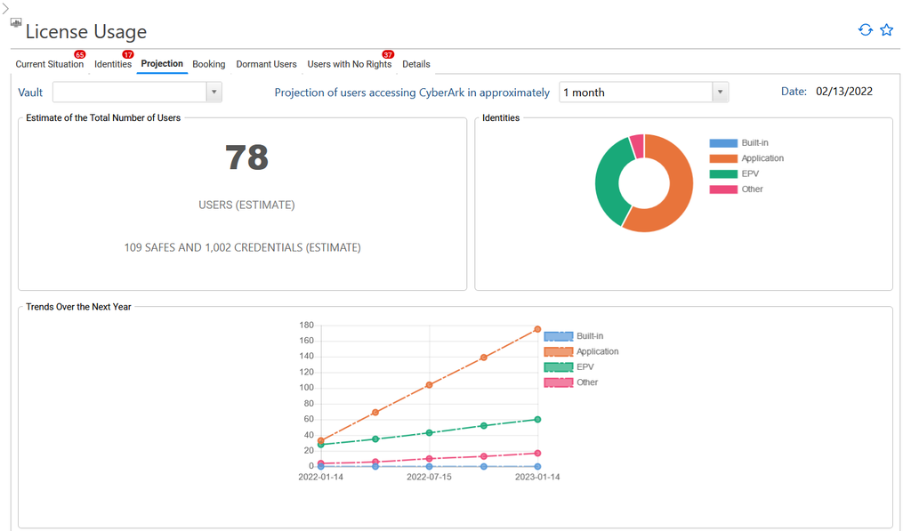

### The User Access Review Challenge

Access review is often key when working within compliance restrictions (Sarbanes Oxley 404 for financial systems, CRBF 97-.02 in the world of banking, Solvency II in the insurance world, and ISAE 3402 for hosting companies, to name but a few). For this reason it is included in most security policies, including those based on the ISO standard number 27002.

#### What is an access review?

An access review shows whether a person’s rights to access an application (or in our case here a safe) comply with a company’s access management policy. It involves getting managers to check all the rights of their staff to access applications, or safe owners to check all the access rights to their safes. It is an essential part of a company’s information security and an effective access review will provide a list of all wrongly assigned rights. This list is then used to correct access rights and avoid failures in security. The result is no more risk of fraud, leaks of information, or problems linked to non-compliance.

An organization’s information system is constantly changing as are the people involved in it. Access reviews must be carried out regularly. Security standards set the minimum frequency at once per year, but in practice it needs to be carried out every three months to effectively tackle the risks of fraud and data leakage.

#### Who carries out safe access reviews?

The unit in charge of security is often responsible for preparing and organizing access reviews. However it is not always responsible for CyberArk PAM. Good practice assigns this responsibility to the PAM team. In PAM Booster, all end-user with the role “pamadmin” can prepare and configure review campaigns. Those end-users are named “review campaign owners”.

#### Who are the reviewers?

Several options are available depending on the organization context.  
By applying the RACI principles, PAM Booster automatically designates the “Accountable” persons as reviewers. The reviewer also has the ablility to ask for help to a colleague (who would be “Responsible”) or to indicate that he is not the reviewer (not “Accountable”).

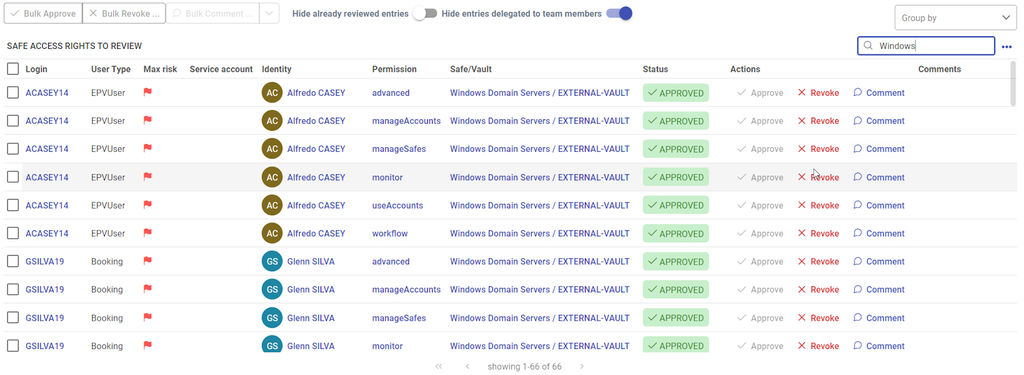

Depending on the strategy the end-user choose, the accountable people can be either the safe owner (e.g. “All users by safe owner”), the operational manager of the identity(“EPV users by the line manager…”), the identity owner of the user (“EPV users by themself…”) or the default reviewer set by the review campaign owner.

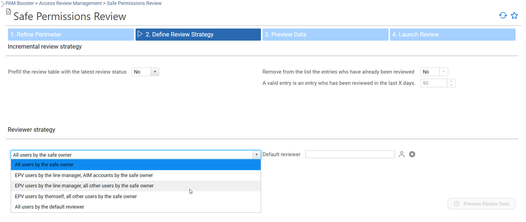

### How safes owner are detected by PAM Booster

When data is loaded, safe owners are automatically detected by PAM Booster.  
By default, everyone with a “ManageSafe” authorization is considered to be the owner of the related safe.  
It is possible to modify this rule during the installation of PAM Booster to meet the organization context.  
It is also possible to remove or add safe owners on the Safe Detail page.

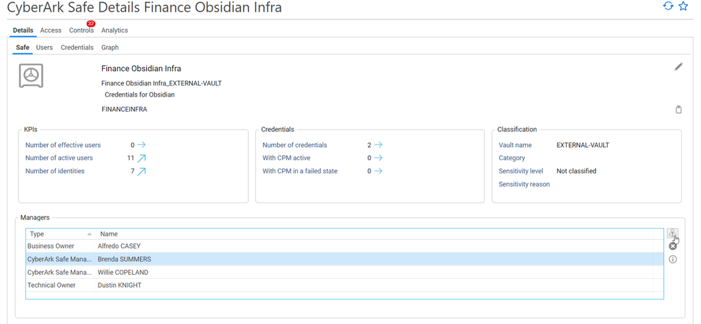

Four types of safe owner are available: - CyberArk Safe Manager, which is safe owners automatically detected by PAM Booster, - Business Owner, which can be added by the end-user, - Technical Owner, which can also be added by the end-user, - Reviewer Owner, which is the default reviewer when safe access review is performed.

When a review campaign is launched, the following is the default list of owners that will be solicitated by priority: - the first “Reviewer”, - if no “Reviewer”, the first “Business Owner”, - if no “Business Owner” the first “CyberArk Safe Manager”, - if no “CyberArk Safe Manager”, the “default reviewer” defined by the review campaign owner will be set as accountable for the entries to review.

##### The safe access review

These reviews involve asking a safe manager to check that access rights are correctly configured for his safe.

This exercise is usually focused on a sub-set of access users:  
1. Users with wider access rights 2. Technical accounts, known as ‘AIM accounts’ that are not linked to particular individuals.

It is not unusual for these two types of review to lead to additional sub-types of review, depending on the targets:

- Distribution list reviews,
- Orphaned user account reviews (accounts for which an owner cannot be found and that have not been detected/set as technical accounts),
- Dormant user account reviews,
- EPV user account reviews,
- AIM account reviews,
- Booking account reviews,
- Etc.

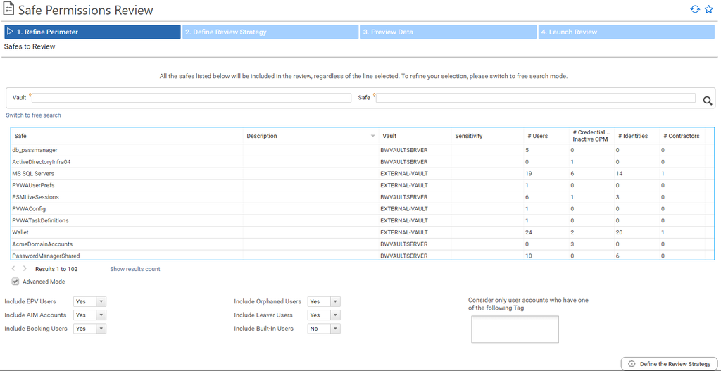

#### How can you tell if an access right is valid?

There are two fundamental principles that enable the validation of access rights:

- The principle of the lowest rights: assigning only the rights that are strictly necessary to users. If a person has no particular need for a resource they should not have access to it.
- The principle of separation of tasks: those who originate a request should not be the same as those who carry it out and those who validate it. This is a first stage that helps avoid lots of errors and slip-ups later on.

In practice, without a formal security policy which defines the precise roles of all those involved, the legitimacy of access rights is left to managers to decide and who alone must assess the usefulness and the risks associated with the access rights assigned.

If a company has formalized the methods for assigning access rights, particularly via applications portals involving staged approval, the associated traces are a source of extra information that help to ensure the validity of the access rights assigned.

#### The major stages in an access review

Carrying out an access review involves several stages and several actors.

One of the first stages involves checking the data quality: can the data be used as it is or does it need to be reworked to make it usable?

Next, all available information must be gathered to compare one against the others. Such information is necessarily heterogenous, e.g. AD, LDAP, CyberArk PAM, CyberArk Privilege Cloud, etc. In order to read and compare it, it must first be consolidated, *i.e.* formed into a single, structured source of data containing all the required information, *e.g.* all owners of access accounts arranged by the departments in which they work, etc.

The information must be rapidly comprehensible by those who have to read and validate it. This may involve improving the syntax of certain data, filtering (not displaying data that is not required for the decision making process), highlighting, etc.

The conduct of the review in itself involves asking numerous actors, heads of departments, and safe owners to validate the information. The organization of this stage is crucial to the success of the review and often requires several awareness exercises, reminders, and so on.

Lastly, when all the above stages have been completed and errors have been identified, it must be possible to correct those errors. The correction process sometimes involves several tasks and several actors. It is only when this stage has been completed that the review is considered finalized.

#### Why is it difficult to carry out safe access reviews?

Obviously, an access review involves two major difficulties:

1. Getting an overall picture of people and their access rights.
2. Organizing and motivating a large number of actors.

##### Putting together an overall picture of people and of access rights to CyberArk.

This catalog of access rights provides the answers to the following questions:

- Who works for the organisation and where?
- What are their rights within CyberArk and to what safe do they have access?
- Which accesses have been used and by whom?
- Collating all this information often requires cross-checking dozens of different files. All too often this is done manually, which is very costly and results in poor quality catalogs.

Underestimating the importance of this stage will not only cause the associated costs to spiral, but also ensure that the data presented for validation will be at best partial, and at worst incorrect, and will in fact result in it being rejected by those in charge of validation.

##### Organizing a large number of actors to ask them to validate the correctness of the rights of access that have been assigned.

It should be remembered here that most of these people will not be from the IT department and, therefore, they should be presented with relevant information, which will enable them to make decisions. All too often reviews merely present technical information, such as groups of accounts (Active Directory, etc.), whereas it would be much better to have the rights validated via these groups (rights to manage safe, access to use credentials, etc.).

Their time is also limited and this operation is perceived as time-consuming. Therefore, all unnecessary stages should be avoided. For example, it is pointless to validate unchanged pieces of information, four times a year, or to have all access rights validated without considering the critical nature of some rights.

A lack of empathy between the actors often leads to rubber stamping signature of reviews. This gives a semblance of compliance, but when all is said and done, everyone has wasted their time.

As you will discover in the following chapter PAM Booster solves this problem thanks to its self-service, compliance driven, access review capabilities.

### PAM Booster Safe Access Review Overview

PAM Booster embeds compliance driven user access review interface. Through this interface you can configure an access review perimeter and run an access certification campaign. Users will then have to review their entries either online through the GUI or offline thanks to Microsoft Excel spreadsheet reports. At the end of the day, this interface also manages the remediation process so that you are sure that all decisions taken during the access certification campaign are enforced.

Here is a quick list of the features available in compliance drive access review:

- Can configure a precise perimeter of what needs to be reviewed
- Can mix organisational review and safe access review in a single campaign
- Can run multiple campaigns at once
- Can automatically identify for each entry to review who is accountable for the review
- Can launch both a global/full access review or an incremental campaign focusing only of what changed since the last review
- Provides rich review end user interface including
  - risk scoring
  - identity context and authorization context
  - review history information
  - filtering capabilities
  - reordering capabilities
  - bulk operations
  - self-service entries reassignment to peers (colleagues / other application owners) by enforcing RACI principles
  - exporting review data in excel format
  - running the review offline through excel spreadsheets
- Provides rich review management interface including
  - KPIs to follow up the campaign progress
    - review perimeter
    - Nb of safes to review
    - Nb of reviewers
    - Reviewed entries so far
    - Actions identities so far
    - Statistics around the nb of entries to review per reviewer (percentile, min, max, …)
    - Completion ratio
    - Decision synthesis
    - Campaign activity
    - Backlog
    - …
  - Real time view of the entries being reviewed with filtering/grouping/export capabilities and identity/permission context
  - Real time view of the actions identified so far with filtering/grouping/export capabilities and identity/permission context
  - Bulk review operations as an administrator
  - Reassigning review entries
  - Review campaign planning overview
  - Mail notification capabilities, including if needed entries to review as a dynamic attachment
  - Mail gentle-reminder capabilities, including if needed entries to review as a dynamic attachment
  - Generate, archive and provide digitally signed PDF compliance reports
- Provides both an embedded remediation workflow and ITSM connectivity to ServiceNow and JIRA to delegate remediation activities to a third party ITSM
- Provides rich remediation end user interface including
  - risk scoring
  - identity context and permission context
  - filtering capabilities
  - reordering capabilities
  - bulk operations
  - exporting remediation data in excel format
- Provides rich remediation management interface including
  - Tracking each requested remediation with a dedicated remediation process (new, in progress, done, won’t fix)
  - KPIs to follow up the remediation progress
    - Total nb of remediation
    - Nb of active remediation
    - Nb of active remediation > 7 days
    - Nb of remediation done
    - Nb of remediation cancelled
    - Remediation velocity
    - Active remediation status
    - …
  - Real time view of the entries being remediated with filtering/grouping/export capabilities and identity/permission context
  - Real time view of the discrepancies identified so far with filtering/grouping/export capabilities and identity/permission context
  - Bulk remediation operations as an administrator
  - Mail notification capabilities
- When leveraging ServiceNow and JIRA for remediation, retrieve tickets numbers and track tickets status upon completion. Automatically spot discrepancies (action marked as done in ServiceNow or Jira and access still active in the target system…).

## Operational Efficiency

The second panel “Operational Efficiency” deals with several challenges related to configuration best practices and CyberArk platform hardening.

### The Challenge of Empowering the Safe Owner

How to provide visibility to the safe owners about who can access the safes they own? What has changed? What are the new users, the new credentials secured in their safes? What are the new issues (control defects) detected by PAM Booster?  
Using the report subscription feature, you can subscribe a selection or all of your safe owners to an email notification that includes an Excel report. In this Excel report, the safe owner will have access to all the information about his safes provided by PAM Booster.

It allows the safe owner to carry out the first level of necessary controls within the framework of the security policy.  
It contains information about user access to his safes and their credentials. In addition, it shows the results of various verifications and security checks.  
Additionally, a time-based analysis is conducted on the data to show any changes that have occurred since the last analysis was performed by PAM Booster.

If safe owners also have access to PAM Booster, they can change the scope of their subscription or stop it altogether by going to the last “Analytics” tab on the “My 360° Access” home page and selecting “My Reports Notification About My Safes.”

## Onboarding into CyberArk

The goal of this last panel is to provide you insight about the onboarding velocity, to follow over time the changes and the evolution of the credentials and resources onboarded into CyberArk. The data presented here is understandable to non-CyberArk experts such as safe and team leaders and management so that you can easily communicate about the progress of the PAM program.

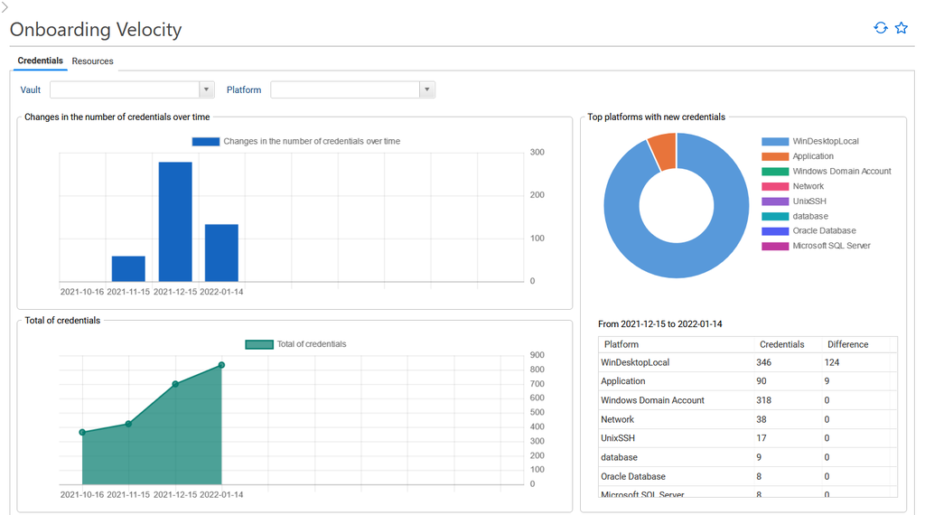

# Analytics on CyberArk Concepts

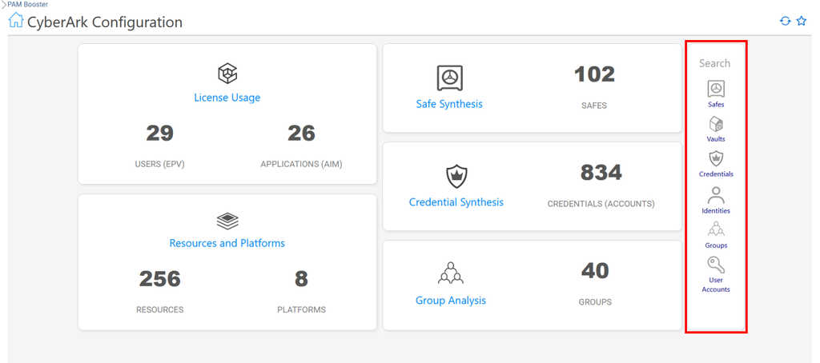

## Search Pages

These search pages are provided per entity (Safe, Vault, Credential, CyberArk User (effective), User Account (all accounts in all repositories), Group, Identity, Organization and more). The goal of the Search page is to provide the ability to investigate on any of these entities, to create search functions and to build your own mashup dashboards.

Tons of KPIs are pre-computed and attached to the entities, most of them are available in the search pages, thus facilitating analysis from the search results:

```
number of safes in a vault,
number of contractors having access to a vault or a safe,
number of credentials,
number of EPV users,
number of credentials with failed CPM,
…
```

Right click on the search table and select “configure” to show/hide the KPIs.

In addition, by clicking the “Compute KPI trends” checkbox at the bottom left of this page, you can display trends with regard to the comparison period (timeslot), which is by default the previous data load.

Here is the vault search page:

[figure not shown]

Here is the safe search page:

[figure not shown]

Here is the credential search page:

[figure not shown]

Here is the CyberArk user search page that lists the effective users (users who have logged into CyberArk at least once and are actually using a license seat):

[figure not shown]

## Detail Pages

All detail pages follow the same navigation logic.

The detail pages presents a 360° view of the selected entity, information is available through a series of tabs. PAM Booster dynamically pre-compute the tabs content and automatically hide most of the tabs if they are empty/not relevant in the context. This greatly simplify the browsing. As a general rule, consider that if a tab is not present it is because its content is empty.

Please note also that most of the components (Table and Pivot Table) are configurable in a way that the end-user can configure the columns that he wants to display as well as their order. He can also export the table/pivot table content in Excel format. Right click on the widget in order to do so.

The vault detail page includes:

```
- Detail of the vault with KPIs,
- List of users having management or audit rights on the vault,
- List of safes in the vault,
- Graph of user access chain to the vault,
- The access rights details,
- The control defect list regarding users with access to the vault.
```

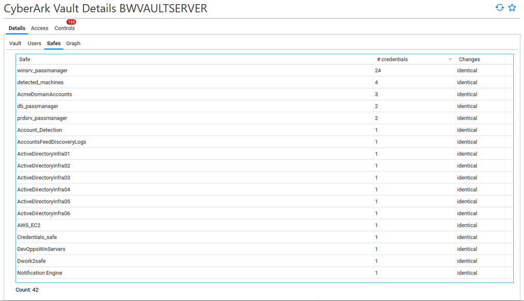

The safe detail page includes:

```
- Detail of the safe with KPIs,
- List of users of the safe,
- List of credentials in the safe,
- Graph of user access chain to the safe,
- The access rights details,
- The control defect list regarding users with access to the safe,
- Analytics reports such as a timeline of changes, orphaned account dashboard, access right analysis, access group analysis.
```

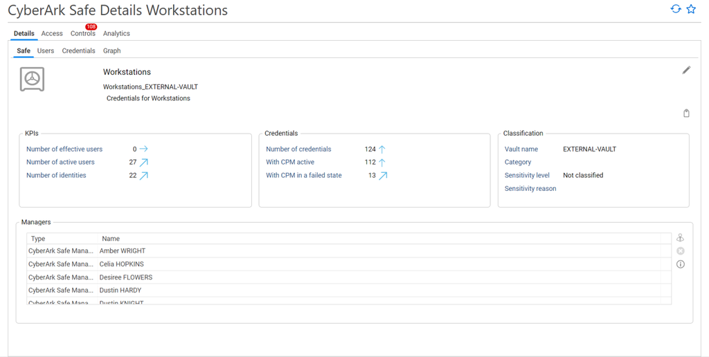

The credential detail page includes:

```
- Detail of the credential with KPIs,
- List of users having access to the credential,
- Graph of user access chain to the credential,
- The access rights details,
- The control defect list regarding users with access to the credential.
```

[figure not shown]

The CyberArk users detail page includes:

- Detail of the CyberArk user with KPIs,
- Detail of the owner of the CyberArk user (the identity who owns the user account),
  - List of groups the CyberArk user is a member of (it includes CyberArk local groups, AD and LDAP groups),
  - The access rights details with the list of Vaults and related authorization, safes and related authorizations, the graph of user access chain to the credential,
  - The control defect list regarding the CyberArk users,
- analytics with the “CyberArk user timeline” report.

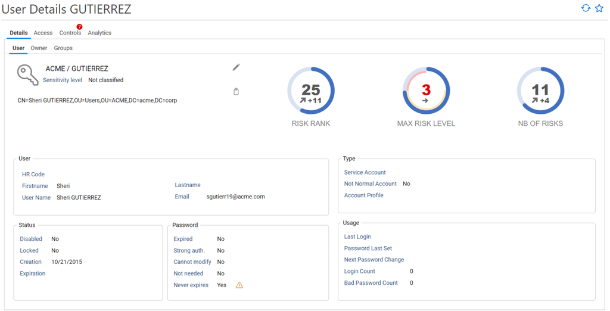

© 1995-2023 [Radiant Logic](https://developer.radiantlogic.com/)